# Programming Assignment - Part 3

Random number generation

```python
%matplotlib inline
from pylab import rcParams
rcParams['figure.figsize'] = 16, 12
```

## Simulation Study Results

```python
import part3_simstudy
```

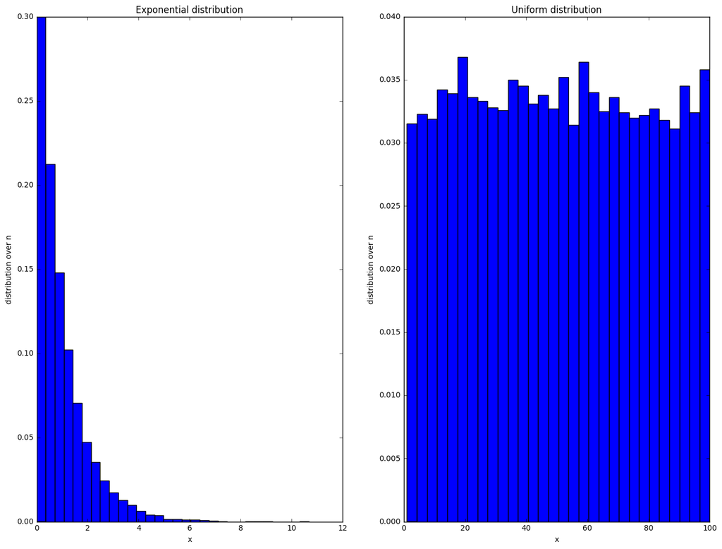

```python
part3_simstudy.task_3_2_1()
```

```python
reload(part3_simstudy)
part3_simstudy.task_3_2_2()
```

```
Results for simulation time of 100s
rho = 0.01, real system utilization/throughput = 0.0129
rho = 0.5, real system utilization/throughput = 0.5019
rho = 0.8, real system utilization/throughput = 0.7699
rho = 0.9, real system utilization/throughput = 0.8035

Results for simulation time of 1000s
rho = 0.01, real system utilization/throughput = 0.0090
rho = 0.5, real system utilization/throughput = 0.5204
rho = 0.8, real system utilization/throughput = 0.7791
rho = 0.9, real system utilization/throughput = 0.8187
```

## Answers to "Analysis and General Questions"

##### 3.3.1: Seed for Random Number Generation

By using a seed, the simulation results are deterministic and comparable, despite using a random number generator to imitate the real world.

##### 3.3.2: Bins for histograms

It might be good to choose the number of bins according to the rule of thumbs given in the lecture notes. If you choose it too high, you will see many peaks but can't spot the correct distribution. When choosing a number which is too little, your distribution will tend to be uniform, such that you can't identify the curves either.

##### 3.3.3: System Utilization

The above results show, how the actual system utilization/throughput behaves compared to that of the system's rho, i.e. offered traffic. Even though each actual value depends on random number seed, a general trend can be observed after running the simulation with different seeds.

- When rho is small, i.e. 0.01 and 0.5, the actual system utilization will be almost rho (slightly smaller or bigger is possible).
- When rho becomes larger and larger, the actual system utilization will tend to be smaller than rho. Specifically when rho is 0.9, the actual value is around 0.8. This is because the queue has a capacity, which leads to packet drops when consecutive packets arrive with short IATs.

There is a theoretical value out of the analytical form of waiting-loss queueing system (see separate slide). When we simulate for an infinite simulation time, the actual value will converge to the theoretical value.

When choosing an unlimited number of buffer spaces, the theoretical utilization will be equal to the offered traffic rho. If we run it for infinite time, the actual utilization will also converge to rho.